# Inside Item Memory

> This notebook focuses on item memory inside the rooms.

# 1 Overview of the data

The rooms were separated into *Familiar* and *Novel* groups. Participants explored the *Familiar* group at the beginning of the experiment. In the encoding task, they visisted both *Familiar* and *Novel* groups. Their item memory (i.e., in which room they saw the item) was tested in the memory test the next day of the encoding task. **Novelty benefits** on the item memory are examined by comparing the memory performance between the *Familiar* and *Novel* groups.

Participants were also asked to rate how curious they felt about the room. The higher the rating is means they felt more curious about the room. Item memory as a function of curiosity rating was also examined for **curiosity benefits**.

Questionnaires on personal traits regarding curiosity were also administered to participants before the encoding task (i.e., PC and EC). Scores on these questionnaires might be able to predict the item memory or its relationship with curiosity rating.

In the encoding task, there were 6 objects in each room, and the participant saw the object after openning each of the six box. It is possbile that the item memory for the object to some extent depends on the order in which the object was seen. For example, it may be easier to remember where the first and last objects were seen as compared to those in the middle.

# 2 Visual inspection of the data

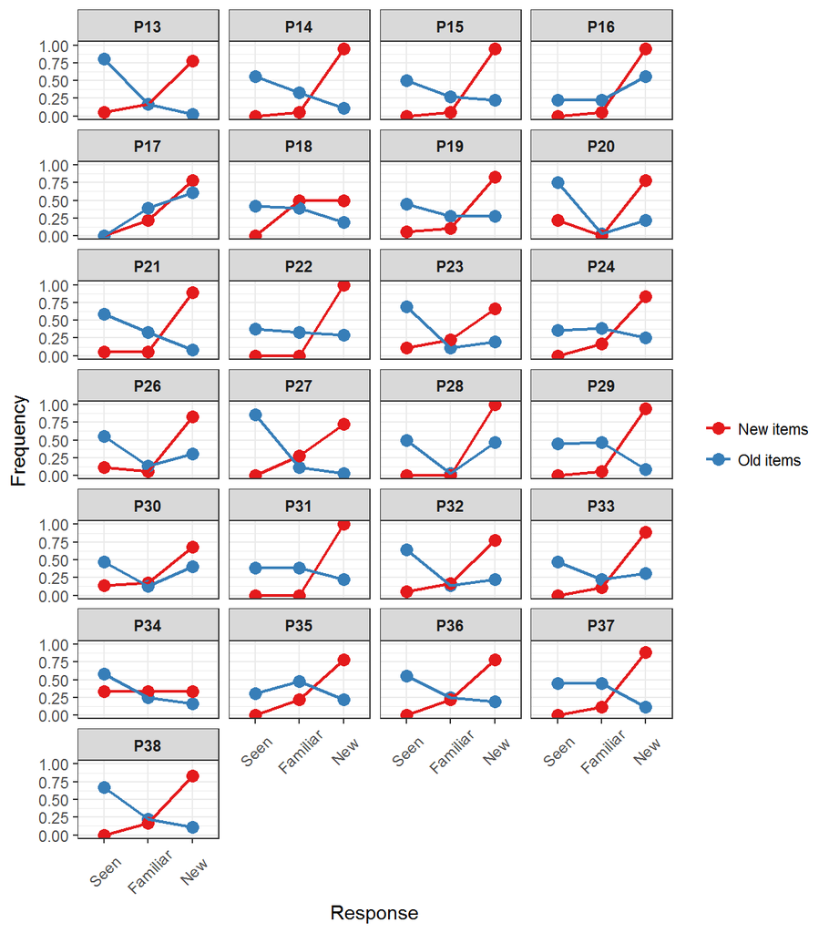

Figure 1. Response frequency for new and old items respectively for each individual participant.

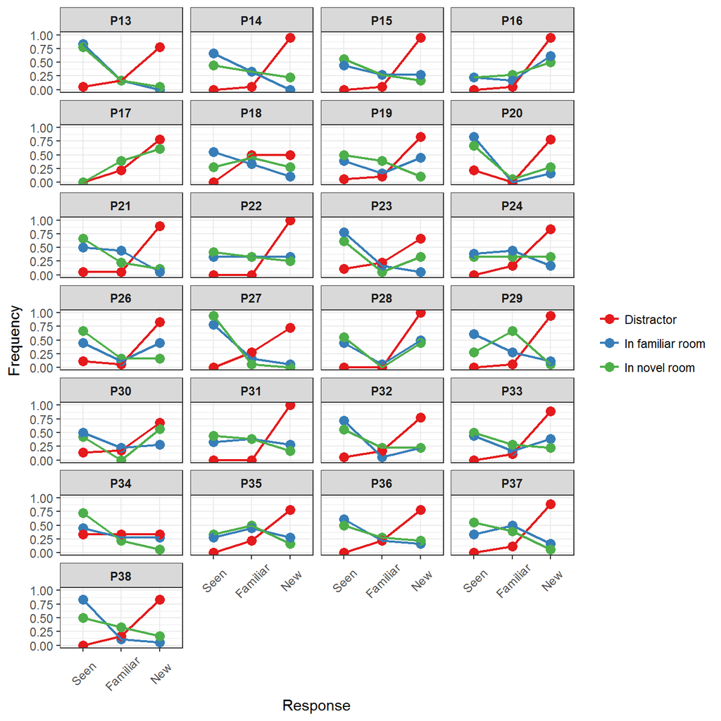

Figure 2. Response frequency for new and old items respectively for each Familiar/Novel group and each individual participant.

# 3 Novelty Benefits

## 3.1 Compare mean accuracy between *novel* and *familiar* rooms

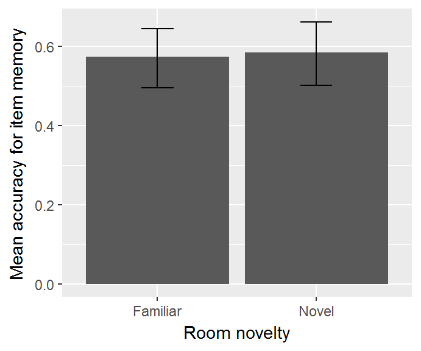

Figure 3. Mean accuracy for item memory respectively for Familiar and Novel rooms.

The mean accuracy of item memory is almost the same between the *familiar* rooms than in the *novel* rooms.

```
##
##  Paired t-test
##
## data:  MeanItemAccuracy by Group
## t = -0.31299, df = 24, p-value = 0.757
## alternative hypothesis: true difference in means is not equal to 0
## 95 percent confidence interval:
##  -0.07594089  0.05594089
## sample estimates:
## mean of the differences
##                   -0.01
```

## 3.2 Item memory as a function of item order

### 3.2.1 Visualise the data

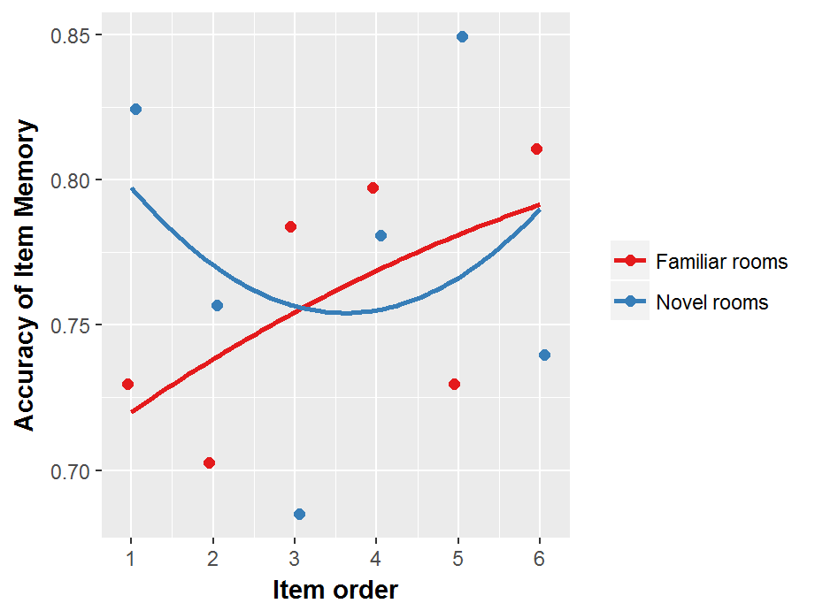

Figure 4. Mean accuracy of item memory for items at each order (i.e., 1st, 2nd, 3rd, etc), respectively for familiar and novel rooms.

### 3.2.2 Testing novelty effects by fitting mixed models

Build models with item memory accuracy as $y$ and iexamine effects of item order and novelty by comparing the models.

- `baseline.item` is the model with only an intercept.
- `order.model.linear.1` is the model with $\small ItemOrder$ included, showing the effects of item order.
- `order.model.linear.2` is the model allowing the slope (i.e., relationship between item memory and item order) varying across participants.
- `order.model.quad.1` and `order.model.quad.2` repectively included $\small ItemOrder^2$ and related random effects.
- `novelty.model.1` is the model with $\small Group$ (i.e., *familiar* and *novel* rooms) included, examining the effects of novelty of the rooms on the intercept (i.e., mean item memory accuracy at the 1st order or overall if no difference in slope).
- `novelty.model.2` is the model with interaction between $\small Group$ and $\small ItemOrder$ included, examining the effects of novelty on how item memory accuracy changes as a function of item order.
- `novelty.model.3` included interaction between $\small Group$ and $\small ItemOrder^2$ for inestigating whether the pattern changes between *familiar* and *novel* groups.

```
##                      Model df      AIC       BIC    logLik   Test
## order.model.linear.1     1  4 947.5117  966.6495 -469.7558
## order.model.linear.2     2  6 950.5267  979.2334 -469.2633 1 vs 2
## order.model.quad.1       3  7 952.2685  985.7597 -469.1342 2 vs 3
## order.model.quad.2       4 10 956.9859 1004.8305 -468.4930 3 vs 4
## novelty.model.1          5 11 958.7639 1011.3930 -468.3820 4 vs 5
## novelty.model.2          6 12 959.7244 1017.1379 -467.8622 5 vs 6
## novelty.model.3          7 13 961.2433 1023.4413 -467.6217 6 vs 7
##                        L.Ratio p-value
## order.model.linear.1
## order.model.linear.2 0.9849854  0.6111
## order.model.quad.1   0.2582066  0.6114
## order.model.quad.2   1.2825726  0.7333
## novelty.model.1      0.2219811  0.6375
## novelty.model.2      1.0395252  0.3079
## novelty.model.3      0.4810704  0.4879
```

Including none of the predictors significantly improved the model fit.

#### 3.2.2.1 Parameter estimation for the complete model

```
## Linear mixed-effects model fit by maximum likelihood
##  Data: Encoding.Recall.Old
##        AIC      BIC    logLik
##   961.2433 1023.441 -467.6217
##
## Random effects:
##  Formula: ~1 + ItemOrder + I(ItemOrder^2) | SubjectNo
##  Structure: General positive-definite, Log-Cholesky parametrization
##                StdDev      Corr
## (Intercept)    0.155777990 (Intr) ItmOrd
## ItemOrder      0.079064176 -0.438
## I(ItemOrder^2) 0.009820384  0.213 -0.948
## Residual       0.399154531
##
## Fixed effects: Accuracy ~ ItemOrder + I(ItemOrder^2) + Group + ItemOrder:Group +      I(ItemOrder^2):Group
##                                Value  Std.Error  DF   t-value p-value
## (Intercept)                0.6997598 0.08897730 854  7.864476  0.0000
## ItemOrder                  0.0208867 0.05675877 854  0.367991  0.7130
## I(ItemOrder^2)            -0.0009470 0.00787146 854 -0.120313  0.9043
## GroupNovel                 0.1384429 0.11789793 854  1.174261  0.2406
## ItemOrder:GroupNovel      -0.0683683 0.07721350 854 -0.885445  0.3762
## I(ItemOrder^2):GroupNovel  0.0074790 0.01080233 854  0.692347  0.4889
##  Correlation:
##                           (Intr) ItmOrd I(ItO^2) GrpNvl ItO:GN
## ItemOrder                 -0.880
## I(ItemOrder^2)             0.793 -0.976
## GroupNovel                -0.661  0.632 -0.584
## ItemOrder:GroupNovel       0.615 -0.677  0.669   -0.931
## I(ItemOrder^2):GroupNovel -0.564  0.663 -0.683    0.854 -0.979
##
## Standardized Within-Group Residuals:
##        Min         Q1        Med         Q3        Max
## -2.3613983  0.1414080  0.3817746  0.5944658  1.4794950
##
## Number of Observations: 884
## Number of Groups: 25
```

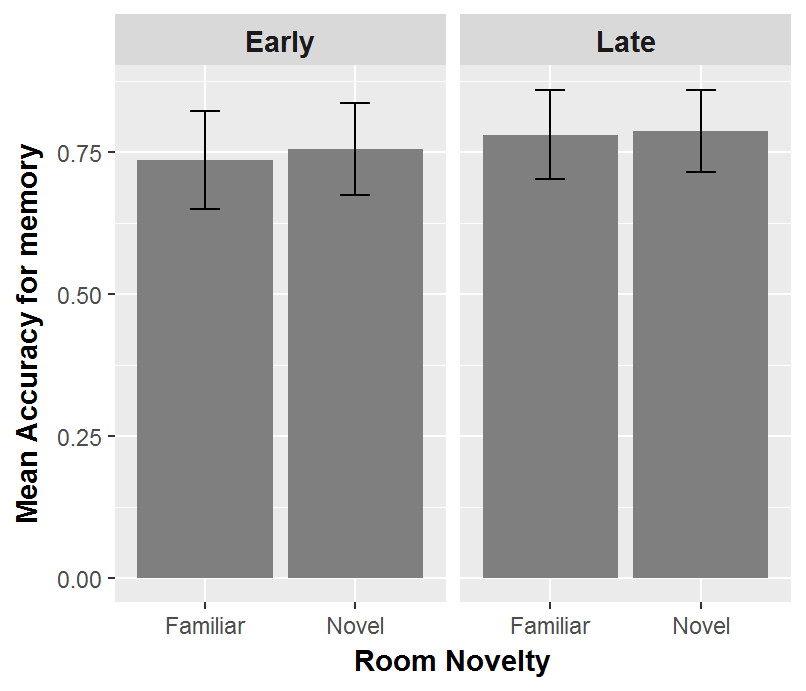

#### 3.2.3.1 Stats on it

```
## Linear mixed-effects model fit by maximum likelihood
##  Data: Encoding.Recall.Old.Collapsed.Grp
##         AIC       BIC   logLik
##   -54.06808 -25.41121 38.03404
##
## Random effects:
##  Formula: ~Group + ItemOrderType | SubjectNo
##  Structure: General positive-definite, Log-Cholesky parametrization
##                   StdDev     Corr
## (Intercept)       0.15160090 (Intr) GrpNvl
## GroupNovel        0.09528189 -0.473
## ItemOrderTypeLate 0.03197564 -0.075 -0.596
## Residual          0.12621045
##
## Fixed effects: Accuracy ~ Group * ItemOrderType
##                                   Value  Std.Error DF   t-value p-value
## (Intercept)                   0.7355556 0.04026574 72 18.267530  0.0000
## GroupNovel                    0.0188889 0.04130012 72  0.457357  0.6488
## ItemOrderTypeLate             0.0444444 0.03701385 72  1.200752  0.2338
## GroupNovel:ItemOrderTypeLate -0.0122222 0.05152520 72 -0.237209  0.8132
##  Correlation:
##                              (Intr) GrpNvl ItmOTL
## GroupNovel                   -0.570
## ItemOrderTypeLate            -0.456  0.385
## GroupNovel:ItemOrderTypeLate  0.320 -0.624 -0.696
##
## Standardized Within-Group Residuals:
##        Min         Q1        Med         Q3        Max
## -2.3832477 -0.4033510  0.1605066  0.6677465  1.1884530
##
## Number of Observations: 100
## Number of Groups: 25
```

# 4 Curiosity Benefits

We hypothesed that the higher the curiosity rating was, the better the item memory should be.

## 4.1 Mean accuracy of item memory as a function of curiosity rating

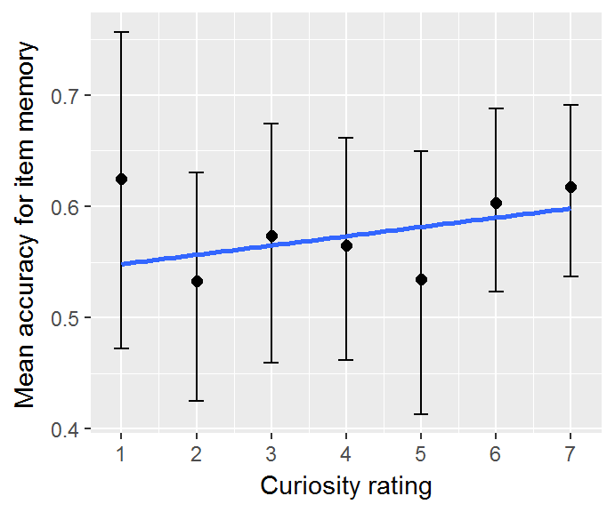

Figure 5. Mean accuracy for item memory as a function of curiosity rating.

There seems to be a weak positive correlation between curiosity rating and item memory **on average**.

### 4.1.1 Testing the relationship between mean accuracy of item memory and curiosity rating

Build models with item memory accuracy as $y$ and examine effects of curiosity rating by including it into the model and then comparing the model fits.

- `baseline.rating` is the model with only an intercept, showing no change in item memory as a function of curiosity rating.
- `rating.intercept` is the model with $\small CuriosityRating$ included, showing the effects of curiosity rating.
- `rating.slope` is the model allowing the slope (i.e., relationship between item memory and curiosity rating) varying across participants.

```
##                  Model df       AIC       BIC   logLik   Test   L.Ratio
## baseline.rating      1  3 -57.04883 -48.05720 31.52442
## rating.intercept     2  4 -56.01719 -44.02834 32.00859 1 vs 2 0.9683550
## rating.slope         3  6 -52.01241 -34.02913 32.00620 2 vs 3 0.0047819
##                  p-value
## baseline.rating
## rating.intercept  0.3251
## rating.slope      0.9976
```

Including $\small CuriosityRating$ did not improve the model fit significantly, so may not play an important role.

#### 4.1.1.1 Parameter estimates in the complete model

```r
summary(rating.slope)
```

```
## Linear mixed-effects model fit by maximum likelihood
##  Data: InsideObjectsMemory
##         AIC       BIC  logLik
##   -52.01241 -34.02913 32.0062
##
## Random effects:
##  Formula: ~1 + CuriosityRating | SubjectNo
##  Structure: General positive-definite, Log-Cholesky parametrization
##                 StdDev      Corr
## (Intercept)     0.178477516 (Intr)
## CuriosityRating 0.001802601 -0.056
## Residual        0.163454139
##
## Fixed effects: ItemAccuracy ~ CuriosityRating
##                     Value  Std.Error  DF   t-value p-value
## (Intercept)     0.5450828 0.05203147 122 10.476020  0.0000
## CuriosityRating 0.0075399 0.00772006 122  0.976665  0.3307
##  Correlation:
##                 (Intr)
## CuriosityRating -0.676
##
## Standardized Within-Group Residuals:
##        Min         Q1        Med         Q3        Max
## -2.4064823 -0.5861055  0.1140244  0.6278061  2.7541214
##
## Number of Observations: 148
## Number of Groups: 25
```

#### 4.1.1.2 Plot the model

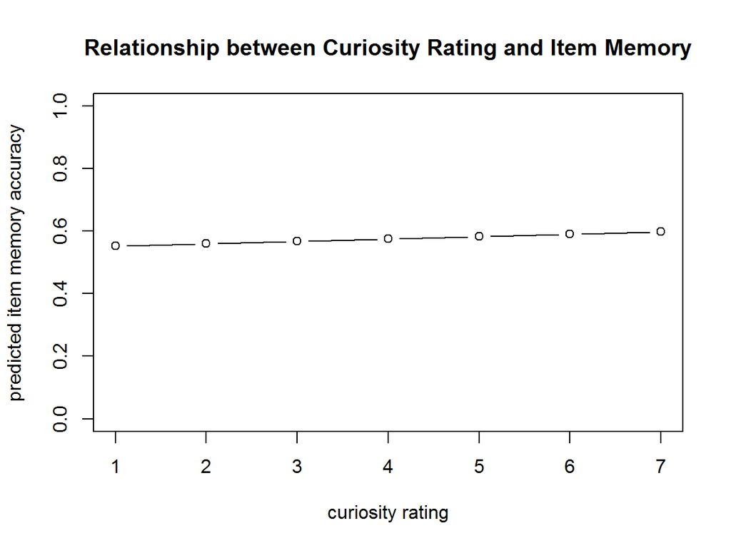

After taking into account individual difference, the estimated slope (relationship between curiosity rating and item memory) is still weakly positive.

## 4.2 Does the relationship with curiosity rating depend on item order?

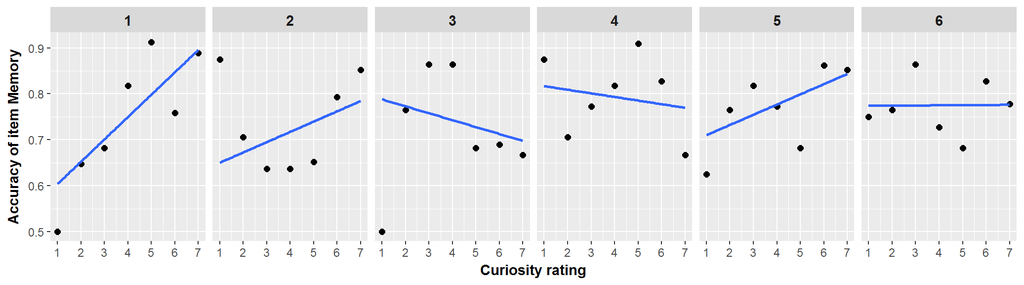

Figure 6. Mean accuracy across participants for item memory as a function of curiosity rating for each order at which the item was seen (I.e., 1st, 2nd, 3rd, etc.).

For three of the six orders, there seems to be a positive correlates between curiosity rating and item memory.

### 4.2.1 Testing the effect of item order

Build models with context memory accuracy as $y$ and examine effects of curiosity rating and item order by comparing the models.

- `item.model.linear.1` is the model with $\small ItemOrder$ included (in addition to $\small CuriosityRating$), showing the effects of item order.
- `item.model.linear.2` is the model allowing the slope (i.e., relationship between item memory and item order) varying across participants.
- `item.model.linear.3` is the model with the interaction between $\small ItemOrders$ and $\small CuriosityRating$ included.
- `item.model.quad.1` and `item.model.quad.2` repectively included $\small ItemOrder^2$ and related random effects.
- `item.model.quad.3` included interaction between $\small ItemOrder^2$ and $\small CuriosityRating$ for inestigating whether the pattern changes as a function of *curiosity rating*.

```r
rating.intercept <- update(baseline.item, .~. + CuriosityRating)
rating.slope     <- update(rating.intercept, random = ~ 1 + CuriosityRating | SubjectNo)

item.model.linear.1     <- update(rating.slope, .~. + ItemOrder)
item.model.linear.2     <- update(item.model.linear.1, random = list(~1+CuriosityRating|SubjectNo, ~1+ItemOrder|SubjectNo))
item.model.linear.3     <- update(item.model.linear.2, .~. + ItemOrder : CuriosityRating)

item.model.quad.1       <- update(item.model.linear.3, .~. + I(ItemOrder^2))
# item.model.quad.2       <- update(item.model.quad.1,   random = list(~1+CuriosityRating|SubjectNo, ~1+ItemOrder+I(ItemOrder^2)|SubjectNo)) - excluding this model because singularity issue (perhaps the model was getting too complex to be calculated)
item.model.quad.3       <- update(item.model.quad.1,   .~. + I(ItemOrder^2) : CuriosityRating)

anova(rating.intercept, rating.slope, item.model.linear.1, item.model.linear.2, item.model.linear.3, item.model.quad.1, item.model.quad.3)
```

```
##                     Model df      AIC       BIC    logLik   Test  L.Ratio
## rating.intercept        1  4 946.8157  965.9535 -469.4079
## rating.slope            2  6 949.9829  978.6896 -468.9914 1 vs 2 0.832843
## item.model.linear.1     3  7 951.3631  984.8543 -468.6816 2 vs 3 0.619743
## item.model.linear.2     4 10 956.2450 1004.0896 -468.1225 3 vs 4 1.118137
## item.model.linear.3     5 11 956.3588 1008.9878 -467.1794 4 vs 5 1.886207
## item.model.quad.1       6 12 958.2885 1015.7020 -467.1443 5 vs 6 0.070283
## item.model.quad.3       7 13 956.8727 1019.0706 -465.4363 6 vs 7 3.415830
##                     p-value
## rating.intercept
## rating.slope         0.6594
## item.model.linear.1  0.4311
## item.model.linear.2  0.7727
## item.model.linear.3  0.1696
## item.model.quad.1    0.7909
## item.model.quad.3    0.0646
```

Including none of the predictors improved the model fit significantly.

#### 4.2.1.1 Parameter estimation for the complete model

```r
summary(item.model.quad.3)
```

```
## Linear mixed-effects model fit by maximum likelihood
##  Data: Encoding.Recall.Old
##        AIC      BIC    logLik
##   956.8727 1019.071 -465.4363
##
## Random effects:
##  Formula: ~1 + CuriosityRating | SubjectNo
##  Structure: General positive-definite, Log-Cholesky parametrization
##                 StdDev     Corr
## (Intercept)     0.16884700 (Intr)
## CuriosityRating 0.01385184 -0.858
##
##  Formula: ~1 + ItemOrder | SubjectNo %in% SubjectNo
##  Structure: General positive-definite, Log-Cholesky parametrization
##             StdDev     Corr
## (Intercept) 0.08261282 (Intr)
## ItemOrder   0.01860549 -0.773
## Residual    0.39909879
##
## Fixed effects: Accuracy ~ CuriosityRating + ItemOrder + I(ItemOrder^2) + CuriosityRating:ItemOrder +      CuriosityRating:I(ItemOrder^2)
##                                     Value  Std.Error  DF   t-value p-value
## (Intercept)                     0.4117090 0.16266909 854  2.530960  0.0116
## CuriosityRating                 0.0786400 0.03236101 854  2.430084  0.0153
## ItemOrder                       0.1819876 0.10316433 854  1.764056  0.0781
## I(ItemOrder^2)                 -0.0210929 0.01441296 854 -1.463465  0.1437
## CuriosityRating:ItemOrder      -0.0428139 0.02100001 854 -2.038757  0.0418
## CuriosityRating:I(ItemOrder^2)  0.0052346 0.00293569 854  1.783079  0.0749
##  Correlation:
##                                (Intr) CrstyR ItmOrd I(IO^2 CrR:IO
## CuriosityRating                -0.915
## ItemOrder                      -0.905  0.857
## I(ItemOrder^2)                  0.827 -0.785 -0.978
## CuriosityRating:ItemOrder       0.838 -0.925 -0.927  0.907
## CuriosityRating:I(ItemOrder^2) -0.767  0.847  0.907 -0.927 -0.979
##
## Standardized Within-Group Residuals:
##         Min          Q1         Med          Q3         Max
## -2.39882164  0.08788279  0.41194407  0.58070486  1.59295954
##
## Number of Observations: 884
## Number of Groups:
##                  SubjectNo SubjectNo.1 %in% SubjectNo
##                         25                         25
```

### 4.2.2 Collapse the order and curiosity rating

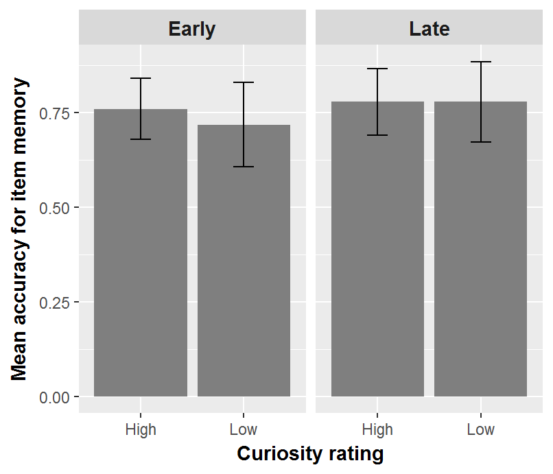

Figure 7. Mean hit rate as a function of item order (Early vs. Late) and curiosity (Low vs. High).

#### 4.2.2.1 Stats on it

```
## Linear mixed-effects model fit by maximum likelihood
##  Data: Encoding.Recall.Old.Collapsed
##         AIC       BIC   logLik
##   -27.76398 0.4438471 24.88199
##
## Random effects:
##  Formula: ~CuriosityRatingType + ItemOrderType | SubjectNo
##  Structure: General positive-definite, Log-Cholesky parametrization
##                        StdDev     Corr
## (Intercept)            0.13813180 (Intr) CrsRTL
## CuriosityRatingTypeLow 0.07376687  0.412
## ItemOrderTypeLate      0.03680565  0.580 -0.442
## Residual               0.14403387
##
## Fixed effects: Accuracy ~ CuriosityRatingType * ItemOrderType
##                                               Value  Std.Error DF
## (Intercept)                               0.7588485 0.04077142 68
## CuriosityRatingTypeLow                   -0.0501494 0.04570526 68
## ItemOrderTypeLate                         0.0187071 0.04228903 68
## CuriosityRatingTypeLow:ItemOrderTypeLate  0.0405091 0.06014659 68
##                                            t-value p-value
## (Intercept)                              18.612264  0.0000
## CuriosityRatingTypeLow                   -1.097234  0.2764
## ItemOrderTypeLate                         0.442362  0.6596
## CuriosityRatingTypeLow:ItemOrderTypeLate  0.673506  0.5029
##  Correlation:
##                                          (Intr) CrsRTL ItmOTL
## CuriosityRatingTypeLow                   -0.371
## ItemOrderTypeLate                        -0.431  0.422
## CuriosityRatingTypeLow:ItemOrderTypeLate  0.353 -0.659 -0.681
##
## Standardized Within-Group Residuals:
##        Min         Q1        Med         Q3        Max
## -2.3972312 -0.4447543  0.1951801  0.6427530  1.6967849
##
## Number of Observations: 96
## Number of Groups: 25
```

# 5 Curiosity and novelty

## 5.1 Testing the effects of curiosity rating and novelty together

Build models with item memory accuracy as $y$ and examine effects of curiosity rating and novelty together by including them into the model separately and then comparing the model fits.

```
##                   Model df       AIC       BIC   logLik   Test   L.Ratio
## baseline.rating       1  3 -57.04883 -48.05720 31.52442
## rating.intercept      2  4 -56.01719 -44.02834 32.00859 1 vs 2 0.9683550
## rating.slope          3  6 -52.01241 -34.02913 32.00620 2 vs 3 0.0047819
## novelty.model.1       4  7 -50.29550 -29.31501 32.14775 3 vs 4 0.2830924
## novelty.model.2       5 10 -45.34876 -15.37664 32.67438 4 vs 5 1.0532611
## interaction.model     6 11 -44.10707 -11.13773 33.05353 5 vs 6 0.7583077
##                   p-value
## baseline.rating
## rating.intercept   0.3251
## rating.slope       0.9976
## novelty.model.1    0.5947
## novelty.model.2    0.7884
## interaction.model  0.3839
```

```
## Linear mixed-effects model fit by maximum likelihood
##  Data: InsideObjectsMemory
##         AIC       BIC   logLik
##   -45.34876 -15.37664 32.67438
##
## Random effects:
##  Formula: ~1 + CuriosityRating | SubjectNo
##  Structure: General positive-definite, Log-Cholesky parametrization
##                 StdDev       Corr
## (Intercept)     0.1469319916 (Intr)
## CuriosityRating 0.0002996446 -0.008
##
##  Formula: ~1 + Group | SubjectNo %in% SubjectNo
##  Structure: General positive-definite, Log-Cholesky parametrization
##             StdDev     Corr
## (Intercept) 0.10178216 (Intr)
## GroupNovel  0.08191658 -0.182
## Residual    0.15717919
##
## Fixed effects: ItemAccuracy ~ CuriosityRating + Group
##                      Value  Std.Error  DF   t-value p-value
## (Intercept)      0.5555645 0.05488677 121 10.122012  0.0000
## CuriosityRating  0.0058325 0.01122609 121  0.519548  0.6043
## GroupNovel      -0.0053906 0.04188426 121 -0.128702  0.8978
##  Correlation:
##                 (Intr) CrstyR
## CuriosityRating -0.673
## GroupNovel       0.279 -0.674
##
## Standardized Within-Group Residuals:
##        Min         Q1        Med         Q3        Max
## -2.4205103 -0.5757823  0.1272681  0.6265005  2.8812941
##
## Number of Observations: 148
## Number of Groups:
##                  SubjectNo SubjectNo.1 %in% SubjectNo
##                         25                         25
```

## 5.2 What about the other way around

```
##                 Model df       AIC       BIC   logLik   Test   L.Ratio
## baseline.rating     1  3 -57.04883 -48.05720 31.52442
## novelty.model.1     2  4 -55.16039 -43.17154 31.58019 1 vs 2 0.1115537
## novelty.model.2     3  6 -53.13094 -35.14767 32.56547 2 vs 3 1.9705548
## rating.model.1      4  7 -51.34903 -30.36854 32.67451 3 vs 4 0.2180877
## rating.model.2      5 10 -45.34876 -15.37664 32.67438 4 vs 5 0.0002694
##                 p-value
## baseline.rating
## novelty.model.1  0.7384
## novelty.model.2  0.3733
## rating.model.1   0.6405
## rating.model.2   1.0000
```

### 5.2.1 Check the model

```
## Linear mixed-effects model fit by maximum likelihood
##  Data: InsideObjectsMemory
##         AIC       BIC   logLik
##   -45.34876 -15.37664 32.67438
##
## Random effects:
##  Formula: ~1 + CuriosityRating | SubjectNo
##  Structure: General positive-definite, Log-Cholesky parametrization
##                 StdDev       Corr
## (Intercept)     0.1469319919 (Intr)
## CuriosityRating 0.0002996446 -0.008
##
##  Formula: ~1 + Group | SubjectNo %in% SubjectNo
##  Structure: General positive-definite, Log-Cholesky parametrization
##             StdDev     Corr
## (Intercept) 0.10178216 (Intr)
## GroupNovel  0.08191658 -0.182
## Residual    0.15717919
##
## Fixed effects: ItemAccuracy ~ Group + CuriosityRating
##                      Value  Std.Error  DF   t-value p-value
## (Intercept)      0.5555645 0.05488677 121 10.122012  0.0000
## GroupNovel      -0.0053906 0.04188426 121 -0.128702  0.8978
## CuriosityRating  0.0058325 0.01122609 121  0.519548  0.6043
##  Correlation:
##                 (Intr) GrpNvl
## GroupNovel       0.279
## CuriosityRating -0.673 -0.674
##
## Standardized Within-Group Residuals:
##        Min         Q1        Med         Q3        Max
## -2.4205103 -0.5757823  0.1272681  0.6265005  2.8812941
##
## Number of Observations: 148
## Number of Groups:
##                  SubjectNo SubjectNo.1 %in% SubjectNo
##                         25                         25
```